# Olympic Project

Team 1: Xiaoqi Hu, Siqi Zhang, Yanni Lan, Chenhang Niu, Yuyang Shu, Kyle Blackburn (Team Lead)

# Raw Data

[Data Source](https://www.kaggle.com/heesoo37/120-years-of-olympic-history-athletes-and-results/version/2?)

```python
%%bq query
SELECT *
FROM `cohort-b-team-1.olympic_data.athlete_data`
LIMIT 100
```

| ID | Name | Sex | Age | Height | Weight | Team | NOC | Games | Year | Season | City | Sport | Event | Medal |
| --- | --- | --- | --- | --- | --- | --- | --- | --- | --- | --- | --- | --- | --- | --- |
| 14840 | Andreas Bang Brecke | M | 40 | 0 | 0.0 | Jo | NOR | 1920 Summer | 1920 | Summer | Antwerpen | Sailing | Sailing Mixed 6 metres | Gold |
| 56486 | Paal Kaasen | M | 36 | 0 | 0.0 | Jo | NOR | 1920 Summer | 1920 | Summer | Antwerpen | Sailing | Sailing Mixed 6 metres | Gold |
| 103129 | Ingolf Richard Rd | M | 30 | 0 | 0.0 | Jo | NOR | 1920 Summer | 1920 | Summer | Antwerpen | Sailing | Sailing Mixed 6 metres | Gold |
| 58576 | Godfrey Kenneth Kelly | M | 31 | 175 | 75.0 | Bim | BAH | 1960 Summer | 1960 | Summer | Roma | Sailing | Sailing Mixed Three Person Keelboat | 0 |
| 58585 | Maurice George Kelly | M | 35 | 179 | 79.0 | Bim | BAH | 1960 Summer | 1960 | Summer | Roma | Sailing | Sailing Mixed Three Person Keelboat | 0 |
| 61579 | Percival Andrew "Percy" Knowles | M | 29 | 168 | 70.0 | Bim | BAH | 1960 Summer | 1960 | Summer | Roma | Sailing | Sailing Mixed Three Person Keelboat | 0 |
| 33921 | Philip Vernon le Geyt Falle | M | 43 | 0 | 0.0 | Feo | GBR | 1928 Summer | 1928 | Summer | Amsterdam | Sailing | Sailing Mixed 8 metres | 0 |
| 100798 | Thomas Cooper Riggs | M | 24 | 0 | 0.0 | Feo | GBR | 1928 Summer | 1928 | Summer | Amsterdam | Sailing | Sailing Mixed 8 metres | 0 |
| 102407 | Ernest John Roney | M | 27 | 0 | 0.0 | Feo | GBR | 1928 Summer | 1928 | Summer | Amsterdam | Sailing | Sailing Mixed 8 metres | 0 |
| 102408 | Esmond Richard Roney | M | 20 | 0 | 0.0 | Feo | GBR | 1928 Summer | 1928 | Summer | Amsterdam | Sailing | Sailing Mixed 8 metres | 0 |
| 102409 | Margaret Helena Roney | F | 28 | 0 | 0.0 | Feo | GBR | 1928 Summer | 1928 | Summer | Amsterdam | Sailing | Sailing Mixed 8 metres | 0 |
| 111668 | Thomas G. Skinner | M | 0 | 0 | 0.0 | Feo | GBR | 1928 Summer | 1928 | Summer | Amsterdam | Sailing | Sailing Mixed 8 metres | 0 |
| 22875 | Cecil George Cooke | M | 41 | 188 | 90.0 | Gem | BAH | 1964 Summer | 1964 | Summer | Tokyo | Sailing | Sailing Mixed Two Person Keelboat | Gold |
| 61572 | Durward Randolph Knowles | M | 46 | 176 | 78.0 | Gem | BAH | 1964 Summer | 1964 | Summer | Tokyo | Sailing | Sailing Mixed Two Person Keelboat | Gold |
| 44835 | Donald Jasper Hains | M | 36 | 0 | 0.0 | Jet | CAN | 1952 Summer | 1952 | Summer | Helsinki | Sailing | Sailing Mixed Three Person Keelboat | 0 |
| 50372 | Archibald Howie | M | 44 | 0 | 0.0 | Jet | CAN | 1952 Summer | 1952 | Summer | Helsinki | Sailing | Sailing Mixed Three Person Keelboat | 0 |
| 101358 | John Norman Frank Robertson | M | 23 | 0 | 0.0 | Jet | CAN | 1952 Summer | 1952 | Summer | Helsinki | Sailing | Sailing Mixed Three Person Keelboat | 0 |
| 53291 | James Peter Jaffe | M | 18 | 0 | 0.0 | Joy | GBR | 1932 Summer | 1932 | Summer | Los Angeles | Sailing | Sailing Mixed Two Person Keelboat | Silver |
| 99124 | George Colin Ratsey | M | 26 | 180 | 0.0 | Joy | GBR | 1932 Summer | 1932 | Summer | Los Angeles | Sailing | Sailing Mixed Two Person Keelboat | Silver |
| 30398 | Abraham Everardus "Biem" Dudok van Heel | M | 30 | 172 | 70.0 | Joy | NED | 1948 Summer | 1948 | Summer | London | Sailing | Sailing Mixed Three Person Keelboat | 0 |
| 55791 | Cornelis Wilhelm "Kees" Jonker | M | 39 | 0 | 0.0 | Joy | NED | 1948 Summer | 1948 | Summer | London | Sailing | Sailing Mixed Three Person Keelboat | 0 |
| 124559 | Willem Paul "Wim" van Duyl | M | 28 | 189 | 90.0 | Joy | NED | 1948 Summer | 1948 | Summer | London | Sailing | Sailing Mixed Three Person Keelboat | 0 |
| 21269 | ivind Christensen (Kristensen-) | M | 36 | 170 | 65.0 | KNS | NOR | 1936 Summer | 1936 | Summer | Berlin | Sailing | Sailing Mixed Two Person Keelboat | 0 |
| 47831 | Sigurd Frithjof Herbern (Johannesen-) | M | 35 | 0 | 0.0 | KNS | NOR | 1936 Summer | 1936 | Summer | Berlin | Sailing | Sailing Mixed Two Person Keelboat | 0 |
| 94688 | Willy H. A. Pieper | M | 25 | 0 | 0.0 | Kln | SUI | 1936 Summer | 1936 | Summer | Berlin | Sailing | Sailing Mixed One Person Dinghy | 0 |

(rows: 100, time: 0.7s, 43MB processed, job: job_QagLsPWLdAdNwrbjyr9SOEKV7xlb)

# Problem Statement

The Olympic Games have been a pivotal event in human development, connecting citizens around the world for hundreds of years. Some sports have been around since Ancient Greece (i.e., track and field) while others have been added along the way. Though the Olympic spirit emphasizes competition, inclusion, and the triumph of high-level athletics, statisticians often only look at the quantity of medals as a metric of a country’s success. Our team took an interest in this fact and decided to investigate it further. Our research question surrounds this topic: are there patterns in who wins and who doesn’t? Are medal wins correlated with other interests such as age, gender, season, host city (country), or sports category (from Athens 1896 to Rio 2016)? In this project we try to identify correlations between these factors and medal wins using free Olympic history data online.

# Work Process

1.Gather Olympics data from kaggle.com (above)

2.Download full set in .csv form

3.Create instance on GCP through Cloud shell in order to run Notebook in Google Cloud Datalab

4.Create bucket in Google Cloud Project, to then make a table in Big Query. When adding the data to a table in Big Query, it did not go nicely and would not correctly detect schema. So we individually assigned the correct schema, field by field.

5.Use Big Query to select data relevant to our research questions

6.Create a Dashboard via Google DataStudio

7.Potentially perform further prediction analysis through R/Python for the 2020 Olympics

## Summer: Sports and Events

The background behind this query is to provide contextual information of the expansion of the Olympics overtime. A growing number of sports (which also equates to a higher number of events per sport) means a higher number of opportunities to earn medals of any color. Thus, when researching information about medal counts over time, it was important to look at how medal opportunities changed as well. We wanted to include as much information as possible, so we divided up winter and summer Olympics to stratify information groups.

```python
%%bq query -n summer_events_time
SELECT Year, COUNT(DISTINCT Sport) as num_sports, COUNT(DISTINCT Event) as num_events
FROM `cohort-b-team-1.olympic_data.athlete_data`
WHERE Season = 'Summer'
GROUP BY Year
ORDER BY Year ASC
```

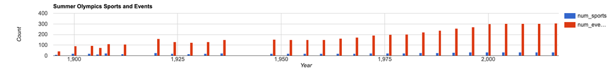

```python
%%chart columns --data summer_events_time
title: Summer Olympics Sports and Events
hAxis:
  title: Year
vAxis:
  title: Count
legend: True
```

## Winter: Sports and Events

```python
%%bq query -n winter_events_time
SELECT Year, COUNT(DISTINCT Sport) as num_sports, COUNT(DISTINCT Event) as num_events
FROM `cohort-b-team-1.olympic_data.athlete_data`
WHERE Season = 'Winter'
GROUP BY Year
ORDER BY Year ASC
```

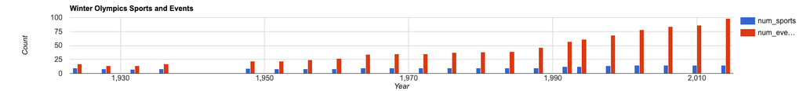

```python
%%chart columns --data winter_events_time
title: Winter Olympics Sports and Events
hAxis:
  title: Year
vAxis:
  title: Count
legend: True
```

## 1900 Summer Events Breakdown

```python
%%bq query -n 1900_events
SELECT Sport, COUNT(DISTINCT Event) as num_events
FROM `cohort-b-team-1.olympic_data.athlete_data`
WHERE Season = 'Summer'AND Year = 1900
GROUP BY Sport
ORDER BY num_events DESC
```

```python
%%bq query -n 1900_breakdown
SELECT
    *,
    ROUND(num_events/(SELECT SUM(num_events) FROM `cohort-b-team-1.olympic_data.1900_events_breakdown`)*100,2) AS perc
FROM
`cohort-b-team-1.olympic_data.1900_events_breakdown`
Limit 5
```

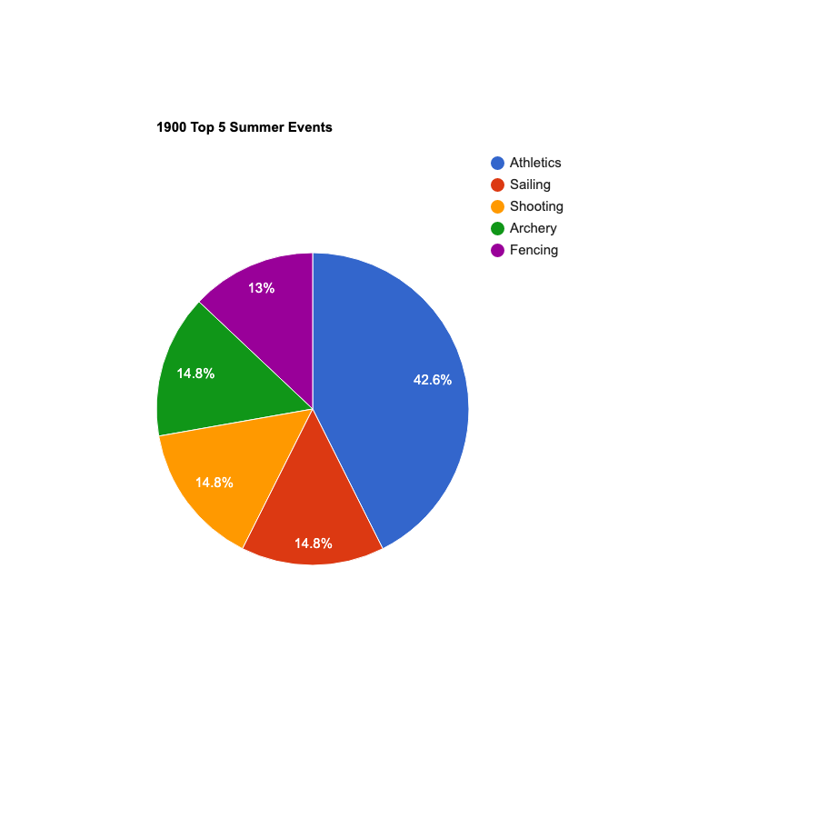

```python
%%chart pie --data 1900_breakdown
title: 1900 Top 5 Summer Events
height: 900
width: 900
legend: True
```

## 2016 Summer Events Breakdown

```python
%%bq query -n 2016_events
SELECT Sport, COUNT(DISTINCT Event) as num_events
FROM `cohort-b-team-1.olympic_data.athlete_data`
WHERE Season = 'Summer'AND Year = 2016
GROUP BY Sport
ORDER BY num_events DESC
```

```python
%%bq query -n 2016_breakdown
SELECT
    *,
    ROUND(num_events/(SELECT SUM(num_events) FROM `cohort-b-team-1.olympic_data.2016_events_breakdown`)*100,2) AS perc
FROM
`cohort-b-team-1.olympic_data.2016_events_breakdown`
LIMIT 5
```

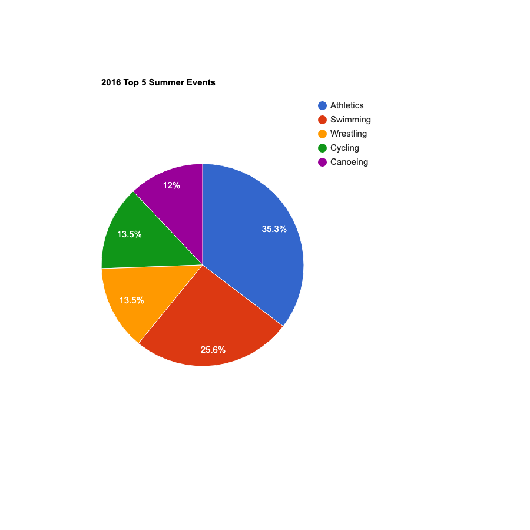

```python
%%chart pie --data 2016_breakdown
title: 2016 Top 5 Summer Events
height: 900
width: 900
legend: True
```

## 1932 Winter Events Breakdown

```python
%%bq query  -n 1932_events
SELECT Sport, COUNT(DISTINCT Event) as num_events
FROM `cohort-b-team-1.olympic_data.athlete_data`
WHERE Season = 'Winter'AND Year = 1932
GROUP BY Sport
ORDER BY num_events DESC
```

```python
%%bq query -n 1932_breakdown
SELECT
    *,
    ROUND(num_events/(SELECT SUM(num_events) FROM `cohort-b-team-1.olympic_data.w_1932_events_breakdown`)*100,2) AS perc
FROM
`cohort-b-team-1.olympic_data.w_1932_events_breakdown`
LIMIT 5
```

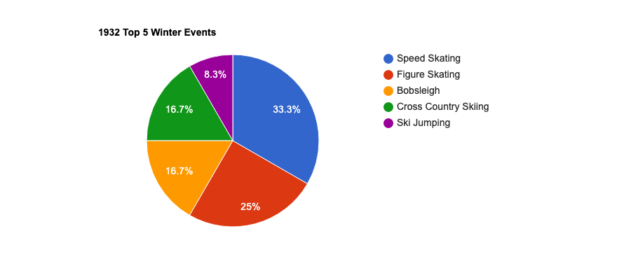

```python
%%chart pie --data 1932_breakdown
title: 1932 Top 5 Winter Events
height: 400
width: 900
legend: True
```

## 2014 Winter Events Breakdown

```python
%%bq query  -n 2014_events
SELECT Sport, COUNT(DISTINCT Event) as num_events
FROM `cohort-b-team-1.olympic_data.athlete_data`
WHERE Season = 'Winter'AND Year = 2014
GROUP BY Sport
ORDER BY num_events DESC
```

```python
%%bq query -n 2014_breakdown
SELECT
    *,
    ROUND(num_events/(SELECT SUM(num_events) FROM `cohort-b-team-1.olympic_data.w_2014_events_breakdown`)*100,2) AS perc
FROM
`cohort-b-team-1.olympic_data.w_2014_events_breakdown`
LIMIT 5
```

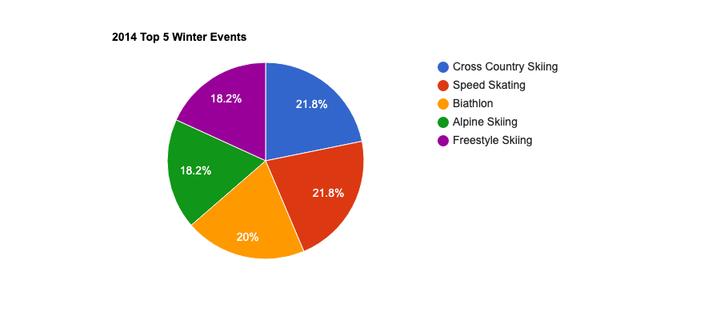

```python
%%chart pie --data 2014_breakdown
title: 2014 Top 5 Winter Events
height: 400
width: 900
legend: True
```

# What's the average, minium and maxium BMI for those players who win the medals?

Here, we are trying to determine if there are any patterns between winning medals and physical traits of the athletes. Granted, this is a bit of a generalization as we realize different sports require varying body shapes and sizes, but we were interested in any overarching patterns.

```python
%%bq query
SELECT ROUND(min(BMI),1) AS min_BMI, round(max(BMI),1) AS max_BMI, ROUND(avg(BMI),1) AS avg_BMI,Sex,Medal
FROM `cohort-b-team-1.olympic_data.BMI_VS_Medal`
Group by Sex,Medal
Order by Sex
```

| min_BMI | max_BMI | avg_BMI | Sex | Medal |
| --- | --- | --- | --- | --- |
| 14.4 | 43.9 | 21.7 | F | Gold |
| 13.5 | 44.5 | 21.6 | F | Bronze |
| 15.0 | 51.0 | 21.6 | F | Silver |
| 15.9 | 50.8 | 24.0 | M | Gold |
| 16.3 | 56.5 | 23.9 | M | Bronze |
| 16.3 | 46.8 | 24.0 | M | Silver |

(rows: 6, time: 0.8s, 553KB processed, job: job_nb87h8RUIWo5sUJ1Syg2YWmnW_Ue)

```python
%%bq query -n BMI_Medal
select Sex,avg_BMI,min_BMI,max_BMI
from(
SELECT ROUND(avg(BMI),1) AS avg_BMI,Sex,ROUND(min(BMI),1) AS min_BMI, round(max(BMI),1) AS max_BMI
FROM `cohort-b-team-1.olympic_data.BMI_VS_Medal`
Group by Sex
Order by Sex)
```

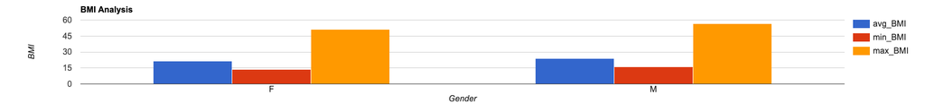

```python
%%chart columns -d BMI_Medal
title: BMI Analysis
hAxis:
  title: Gender
vAxis:
  title: BMI
legend: True
```

## Country VS Medal

This part explains the relationship between counrty and medal won by each country

The following query counts three different medals numbers by country and year from the pervious builded sorted database stored in the GCP Bigquery. Order the result by year and country.

```python
%%bq query
WITH Gold AS(
SELECT NOC, year, COUNT(Medal) AS gold_num
FROM (
SELECT * FROM `cohort-b-team-1.olympic_data.Sorted_Date_For_Country`
WHERE Medal LIKE 'Gold')
GROUP BY NOC, year),
Silver AS(
SELECT NOC, year, COUNT(Medal) AS silver_num
FROM (
SELECT * FROM `cohort-b-team-1.olympic_data.Sorted_Date_For_Country`
WHERE Medal LIKE 'Silver')
GROUP BY NOC, year),
Bronze AS(
SELECT NOC, year, COUNT(Medal) AS bronze_num
FROM (
SELECT * FROM `cohort-b-team-1.olympic_data.Sorted_Date_For_Country`
WHERE Medal LIKE 'Bronze')
GROUP BY NOC, year)


SELECT Gold.year AS year, Gold.NOC AS country, Gold.gold_num AS gold_num, Silver.silver_num AS silver_num, Bronze.bronze_num AS bronze_num
FROM Gold
INNER JOIN Silver
USING (NOC, year)
INNER JOIN Bronze
USING (NOC, year)
Order by year, NOC
```

| year | country | gold_num | silver_num | bronze_num |
| --- | --- | --- | --- | --- |
| 1896 | AUT | 2 | 1 | 2 |
| 1896 | DEN | 1 | 2 | 3 |
| 1896 | FRA | 5 | 4 | 2 |
| 1896 | GBR | 3 | 3 | 3 |
| 1896 | GER | 7 | 5 | 2 |
| 1896 | GRE | 10 | 17 | 17 |
| 1896 | HUN | 2 | 1 | 3 |
| 1896 | USA | 11 | 6 | 2 |
| 1900 | BEL | 6 | 7 | 5 |
| 1900 | DEN | 2 | 3 | 2 |
| 1900 | FRA | 28 | 40 | 34 |
| 1900 | GBR | 19 | 11 | 12 |
| 1900 | GER | 4 | 3 | 1 |
| 1900 | HUN | 1 | 2 | 2 |
| 1900 | NED | 1 | 2 | 4 |
| 1900 | SUI | 6 | 2 | 1 |
| 1900 | USA | 21 | 16 | 17 |
| 1904 | AUT | 2 | 1 | 1 |
| 1904 | CAN | 4 | 1 | 1 |
| 1904 | GER | 4 | 5 | 7 |
| 1904 | HUN | 2 | 1 | 1 |
| 1904 | USA | 76 | 79 | 75 |
| 1906 | AUT | 3 | 3 | 3 |
| 1906 | BEL | 2 | 2 | 3 |
| 1906 | DEN | 3 | 2 | 1 |

(rows: 757, time: 1.0s, 2MB processed, job: job_kWWEDtFim3yJSENF30mb-MLKvH1b)

The following query counts the total medal number won by each country since 1896 categories the results into Gold, Silver and Bronze. Order the results by number of Gold Medal won.

```python
%%bq query
SELECT t1.country as country, SUM(gold_num) as total_gold, t2.total_silver, t3.total_bronze
FROM `cohort-b-team-1.olympic_data.Country_VS_Medal`  t1

LEFT JOIN

(SELECT country as country, SUM(silver_num) as total_silver
FROM `cohort-b-team-1.olympic_data.Country_VS_Medal`
GROUP BY country) t2

ON t1.country = t2.country

LEFT JOIN

(SELECT country as country, SUM(bronze_num) as total_bronze
FROM `cohort-b-team-1.olympic_data.Country_VS_Medal`
GROUP BY country)t3

ON t1.country = t3.country

GROUP BY country,t2.total_silver, t3.total_bronze
ORDER BY total_gold DESC
```

| country | total_gold | total_silver | total_bronze |
| --- | --- | --- | --- |
| USA | 1131 | 901 | 791 |
| URS | 471 | 373 | 353 |
| GER | 319 | 345 | 340 |
| GBR | 286 | 318 | 306 |
| FRA | 264 | 283 | 325 |
| ITA | 246 | 219 | 229 |
| CHN | 239 | 177 | 168 |
| RUS | 201 | 179 | 196 |
| SWE | 197 | 206 | 234 |
| GDR | 192 | 165 | 162 |
| HUN | 173 | 151 | 176 |
| NOR | 155 | 153 | 140 |
| JPN | 151 | 144 | 175 |
| FIN | 146 | 137 | 162 |
| AUS | 143 | 161 | 178 |
| CAN | 124 | 155 | 184 |
| NED | 122 | 116 | 136 |
| KOR | 114 | 95 | 91 |
| SUI | 91 | 110 | 101 |
| ROU | 88 | 94 | 120 |
| AUT | 83 | 110 | 112 |
| POL | 74 | 87 | 132 |
| CUB | 72 | 60 | 70 |
| FRG | 67 | 80 | 91 |
| EUN | 54 | 44 | 37 |

(rows: 71, time: 1.6s, 21KB processed, job: job_qDNsvtyOkK5nLr-ainoPoeJE964R)

The following stores the Result from the query above into "medal_vs_country"

```python
%%bq query -n medal_vs_country
SELECT t1.country as country, SUM(gold_num) as total_gold, t2.total_silver, t3.total_bronze
FROM `cohort-b-team-1.olympic_data.Country_VS_Medal`  t1

LEFT JOIN

(SELECT country as country, SUM(silver_num) as total_silver
FROM `cohort-b-team-1.olympic_data.Country_VS_Medal`
GROUP BY country) t2

ON t1.country = t2.country

LEFT JOIN

(SELECT country as country, SUM(bronze_num) as total_bronze
FROM `cohort-b-team-1.olympic_data.Country_VS_Medal`
GROUP BY country)t3

ON t1.country = t3.country

GROUP BY country,t2.total_silver, t3.total_bronze
ORDER BY total_gold DESC
```

The following commend draws the Barchart base on "medal_vs_country"

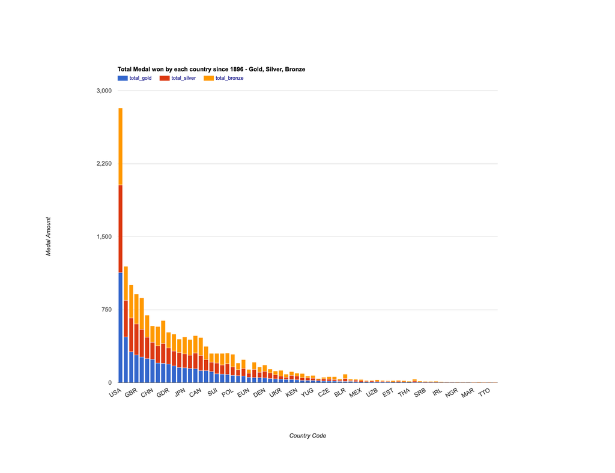

```python
%%chart columns --data medal_vs_country
title: Total Medal won by each country since 1896 - Gold, Silver, Bronze
height: 1500
width: 1950
hAxis:
  title: Country Code
vAxis:
  title: Medal Amount
isStacked:
  true
bar:
  { groupWidth: '75%' }
legend:
  {position: 'top', textStyle: {color: 'navy', fontSize: 16}}
```

The following commend draws the Bubblechart base on "medal_vs_country"

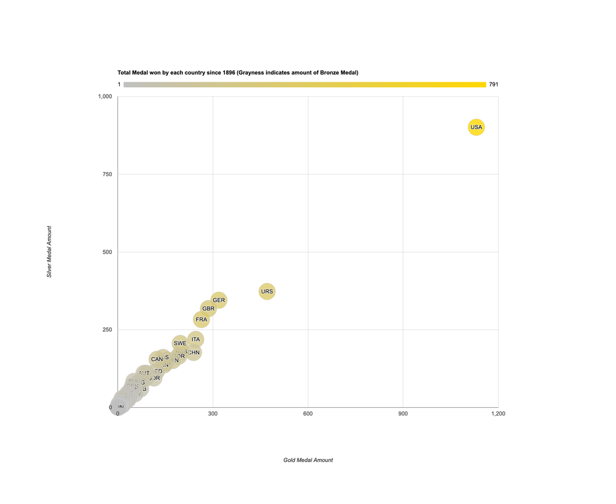

```python
%%chart bubbles --data medal_vs_country
title: Total Medal won by each country since 1896 (Grayness indicates amount of Bronze Medal)
height: 1800
width: 2200
hAxis:
  title: Gold Medal Amount
vAxis:
  title: Silver Medal Amount
colorAxis:
  {colors: ['silver', 'gold']}
```

## City VS Medal

The following table is the number of medals of each host city, listed under year.

```python
%%bq query
WITH Gold AS(
SELECT City, year, COUNT(Medal) AS gold_num
FROM (
SELECT * FROM `cohort-b-team-1.olympic_data.sorted_city`
WHERE Medal LIKE 'Gold')
GROUP BY City, year),
Silver AS(
SELECT City, year, COUNT(Medal) AS silver_num
FROM (
SELECT * FROM `cohort-b-team-1.olympic_data.sorted_city`
WHERE Medal LIKE 'Silver')
GROUP BY City, year),
Bronze AS(
SELECT City, year, COUNT(Medal) AS bronze_num
FROM (
SELECT * FROM `cohort-b-team-1.olympic_data.sorted_city`
WHERE Medal LIKE 'Bronze')
GROUP BY City, year)

SELECT Gold.City AS city, Gold.year AS year, Gold.gold_num AS gold_num, Silver.silver_num AS silver_num, Bronze.bronze_num AS bronze_num
FROM Gold
LEFT JOIN Silver
USING (year,City)
LEFT JOIN Bronze
USING (year,City)
ORDER BY year
```

| city | year | gold_num | silver_num | bronze_num |
| --- | --- | --- | --- | --- |
| Athina | 1896 | 43 | 41 | 32 |
| Paris | 1900 | 89 | 86 | 80 |
| St. Louis | 1904 | 95 | 92 | 88 |
| Athina | 1906 | 74 | 74 | 71 |
| London | 1908 | 109 | 103 | 97 |
| Stockholm | 1912 | 106 | 103 | 100 |
| Antwerpen | 1920 | 154 | 151 | 138 |
| Paris | 1924 | 129 | 130 | 128 |
| Chamonix | 1924 | 17 | 16 | 16 |
| Amsterdam | 1928 | 118 | 118 | 119 |
| Sankt Moritz | 1928 | 13 | 12 | 13 |
| Los Angeles | 1932 | 125 | 125 | 120 |
| Lake Placid | 1932 | 14 | 14 | 14 |
| Berlin | 1936 | 140 | 140 | 140 |
| Garmisch-Partenkirchen | 1936 | 17 | 17 | 17 |
| London | 1948 | 143 | 145 | 147 |
| Sankt Moritz | 1948 | 22 | 22 | 21 |
| Helsinki | 1952 | 149 | 149 | 146 |
| Oslo | 1952 | 22 | 22 | 22 |
| Melbourne | 1956 | 145 | 143 | 142 |
| Cortina d'Ampezzo | 1956 | 24 | 23 | 24 |
| Stockholm | 1956 | 6 | 6 | 6 |
| Roma | 1960 | 150 | 148 | 149 |
| Squaw Valley | 1960 | 27 | 26 | 27 |
| Tokyo | 1964 | 163 | 163 | 160 |

(rows: 52, time: 4.6s, 585KB processed, job: job_4DsgKX_mScwHfJUPNJW84Oqc6drQ)

```python
%%bq query -n city_vs_medal
SELECT * EXCEPT (year)
FROM `cohort-b-team-1.olympic_data.City_VS_Medal`
```

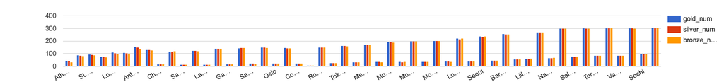

```python
%%chart columns --data city_vs_medal
```

As we can see from the bar chart, the number of gold, silver and bronze are almost equal among each Olympic game. Also, Summer Olypmic games' number of medals are much higher than Winter Olympic games in most case, which there has a increase trendency in the amount of medals if look separately.

## Sex VS Medal

Description: The query below calculated the winning percentage by sex. For all female athletes who participated in Olympic, the rate of those who have medals is around 33%. For all male athletes, this number is about 28%.

# Sex -> M as male athletes, F as female athletes

# Medal_ppl -> the sum number of athletes won the medal regardless of gold, silver, and bronze.

# Total_ppl -> the sum number of athletes who attends the Olympic

# Winning_Percentage -> (Medal_ppl / Total_ppl) *100

```python
%%bq query
SELECT t1.Sex, count(Medal) AS Medal_ppl,total_ppl, ROUND((count(Medal) / total_ppl)*100,0) Winning_Percentage
FROM `cohort-b-team-1.olympic_data.athlete_data` t1
LEFT JOIN
(SELECT Sex,COUNT(DISTINCT ID) AS total_ppl
FROM `cohort-b-team-1.olympic_data.athlete_data`
GROUP BY Sex) t2
on t1.Sex = t2.Sex
WHERE Medal != '0'
Group by Sex,total_ppl
Order by Sex DESC
```

| Sex | Medal_ppl | total_ppl | Winning_Percentage |
| --- | --- | --- | --- |
| M | 28530 | 101590 | 28.0 |
| F | 11253 | 33981 | 33.0 |

(rows: 2, time: 1.6s, 3MB processed, job: job_ktnj2aqyfnKFI59lh4deBTvhlbJP)

```python
%%bq query -n sex_Medal
SELECT t1.Sex, ROUND((count(Medal) / total_ppl)*100,0) Winning_Percentage
FROM `cohort-b-team-1.olympic_data.athlete_data` t1
LEFT JOIN
(SELECT Sex,COUNT(DISTINCT ID) AS total_ppl
FROM `cohort-b-team-1.olympic_data.athlete_data`
GROUP BY Sex) t2
on t1.Sex = t2.Sex
WHERE Medal != '0'
Group by t1.Sex,total_ppl
```

#### Percentage of Winning by Sex

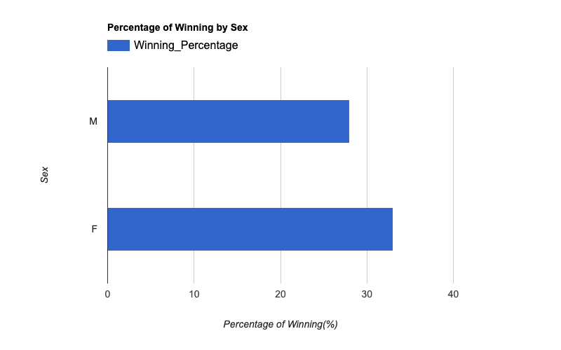

```python
%%chart bars --data sex_Medal
title: Percentage of Winning by Sex
height: 500
width: 800
legend:
  {position: 'top', textStyle: {color: 'black', fontSize: 16}}
hAxis:
  title: Percentage of Winning(%)
vAxis:
  title: Sex
bar:
  { groupWidth: '40%' }
isStacked: True
```

## Age VS Medal

Description: Compared average medal-winning age by gender. The result below illustrates that in general, female medal-winner is younger than male medal-winner. However, the male medal winner also tends to have larger variations on the age range.

```python
%%bq query
SELECT Sex, Medal, ROUND(AVG(Age),1) AS Average_Age, ROUND(STDDEV(Age),1) AS Standard_Deviation
FROM `cohort-b-team-1.olympic_data.athlete_data`
WHERE Medal != '0'
Group by Sex, Medal
Order by Sex DESC, Medal;
```

| Sex | Medal | Average_Age | Standard_Deviation |
| --- | --- | --- | --- |
| M | Bronze | 25.6 | 7.4 |
| M | Gold | 26.1 | 6.8 |
| M | Silver | 25.8 | 7.6 |
| F | Bronze | 24.7 | 5.4 |
| F | Gold | 24.4 | 5.3 |
| F | Silver | 24.4 | 5.3 |

(rows: 6, time: 0.7s, 3MB processed, job: job_GPd_Sgr-Njz5P5Eu8GjdV1iU__5b)

```python
%%bq query -n Age_Medal_Female
SELECT Medal, ROUND(AVG(Age),1) AS Average_Age, ROUND(STDDEV(Age),1) AS Standard_Deviation
FROM `cohort-b-team-1.olympic_data.athlete_data`
WHERE Medal != '0'
Group by Sex, Medal
HAVING Sex ='F'
Order by Sex DESC, Medal
```

#### Average Age and Standard Deviation of Female Athlete Won the Medal

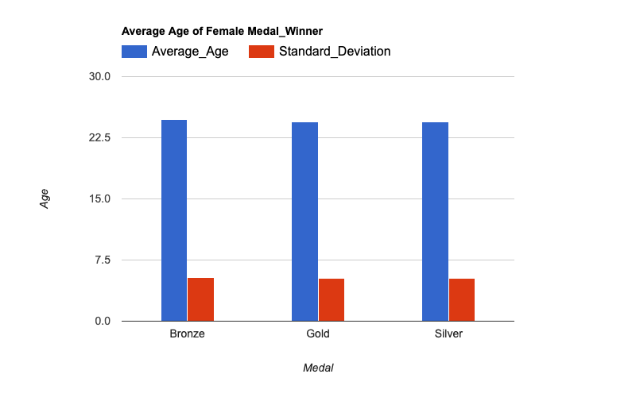

```python
%%chart columns --data Age_Medal_Female
title: Average Age of Female Medal_Winner
height: 500
width: 800
legend:
  {position: 'top', textStyle: {color: 'black', fontSize: 16}}
hAxis:
  title: Medal
vAxis:
  title: Age
bar:
  { groupWidth: '40%' }
```

```python
%%bq query -n Age_Medal_Male
SELECT Medal, ROUND(AVG(Age),1) AS Average_Age, ROUND(STDDEV(Age),1) AS Standard_Deviation
FROM `cohort-b-team-1.olympic_data.athlete_data`
WHERE Medal != '0'
Group by Sex, Medal
HAVING Sex ='M'
Order by Sex DESC, Medal
```

#### Average Age and Standard Deviation of Male Athlete Won the Medal

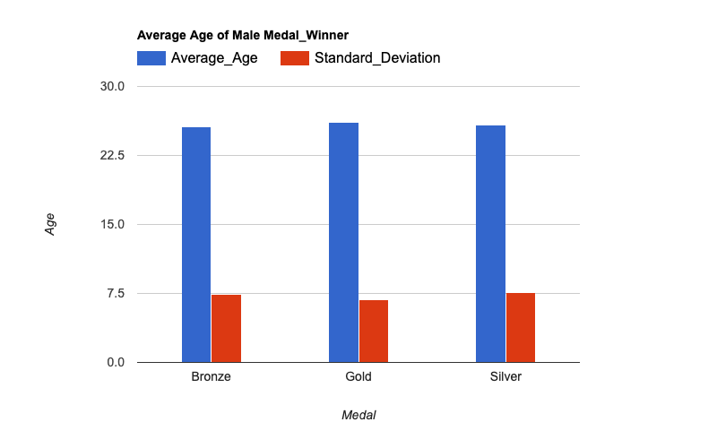

```python
%%chart columns --data Age_Medal_Male
title: Average Age of Male Medal_Winner
height: 500
width: 800
legend:
  {position: 'top', textStyle: {color: 'black', fontSize: 16}}
hAxis:
  title: Medal
vAxis:
  title: Age
bar:
  { groupWidth: '40%' }
```

# Summary

This exploratory research revealed a few interesting trends in among Olympic medal winners. Over time, the chances for winning olympic medals have increased dramatically, in both Winter and Summer. There are some differences between male and female medal winners, both physically and in among other personalistic traits. Additionally, the United States is unsurprisingly a clear winner in the total amount of medals won since 1896. Overall, this exploratory research is a good start into looking at what makes an Olympic medal winner, but lacks in it's predictive capacities (future work needed).